# Pandas Notes 2

## Import lib, load data ...

```python
import pandas as pd

import matplotlib.pyplot as plt
import seaborn as sns

pokedex_fp = './datasets/pokedex_8_generations.csv'
df_all_data = pd.read_csv(pokedex_fp) # for csv Files
# df_all_data = pd.read_csv(pokedex_fp, sep=",", header=0, index_col=0)# for csv files in txt files or with index col
```

## Examine data

Look into the dataset. Rows, Columns, Samples. Rename columns with unnamend/undefined values..

```python
print("The dataset has {} many rows.".format(len(df_all_data)))
df_all_data.rename(columns={'Unnamed: 0': 'id'}, inplace=True) # rename undefined column name
print('The dataset has a shape (rows, columns) of {}'.format(df_all_data.shape))
print(df_all_data.columns) # print all column names
pd.set_option('display.max_columns', len(df_all_data.columns))
df_all_data.head() # print head, you can also print tail
```

```
The dataset has 1028 many rows.
The dataset has a shape (rows, columns) of (1028, 53)
Index(['id', 'pokedex_number', 'name', 'german_name', 'japanese_name',
       'generation', 'is_sub_legendary', 'is_legendary', 'is_mythical',
       'species', 'type_number', 'type_1', 'type_2', 'height_m', 'weight_kg',
       'abilities_number', 'ability_1', 'ability_2', 'ability_hidden',
       'total_points', 'hp', 'attack', 'defense', 'sp_attack', 'sp_defense',
       'speed', 'catch_rate', 'base_friendship', 'base_experience',
       'growth_rate', 'egg_type_number', 'egg_type_1', 'egg_type_2',
       'percentage_male', 'egg_cycles', 'against_normal', 'against_fire',
       'against_water', 'against_electric', 'against_grass', 'against_ice',
       'against_fight', 'against_poison', 'against_ground', 'against_flying',
       'against_psychic', 'against_bug', 'against_rock', 'against_ghost',
       'against_dragon', 'against_dark', 'against_steel', 'against_fairy'],
      dtype='object')
```

|  | id | pokedex_number | name | german_name | japanese_name | generation | is_sub_legendary | is_legendary | is_mythical | species | type_number | type_1 | type_2 | height_m | weight_kg | abilities_number | ability_1 | ability_2 | ability_hidden | total_points | hp | attack | defense | sp_attack | sp_defense | speed | catch_rate | base_friendship | base_experience | … |
| --- | --- | --- | --- | --- | --- | --- | --- | --- | --- | --- | --- | --- | --- | --- | --- | --- | --- | --- | --- | --- | --- | --- | --- | --- | --- | --- | --- | --- | --- | --- |
| 0 | 0 | 1 | Bulbasaur | Bisasam | フシギダネ (Fushigidane) | 1 | 0 | 0 | 0 | Seed Pokémon | 2 | Grass | Poison | 0.7 | 6.9 | 2 | Overgrow | NaN | Chlorophyll | 318.0 | 45.0 | 49.0 | 49.0 | 65.0 | 65.0 | 45.0 | 45.0 | 70.0 | 64.0 | … |
| 1 | 1 | 2 | Ivysaur | Bisaknosp | フシギソウ (Fushigisou) | 1 | 0 | 0 | 0 | Seed Pokémon | 2 | Grass | Poison | 1.0 | 13.0 | 2 | Overgrow | NaN | Chlorophyll | 405.0 | 60.0 | 62.0 | 63.0 | 80.0 | 80.0 | 60.0 | 45.0 | 70.0 | 142.0 | … |
| 2 | 2 | 3 | Venusaur | Bisaflor | フシギバナ (Fushigibana) | 1 | 0 | 0 | 0 | Seed Pokémon | 2 | Grass | Poison | 2.0 | 100.0 | 2 | Overgrow | NaN | Chlorophyll | 525.0 | 80.0 | 82.0 | 83.0 | 100.0 | 100.0 | 80.0 | 45.0 | 70.0 | 236.0 | … |
| 3 | 3 | 3 | Mega Venusaur | Bisaflor | フシギバナ (Fushigibana) | 1 | 0 | 0 | 0 | Seed Pokémon | 2 | Grass | Poison | 2.4 | 155.5 | 1 | Thick Fat | NaN | NaN | 625.0 | 80.0 | 100.0 | 123.0 | 122.0 | 120.0 | 80.0 | 45.0 | 70.0 | 281.0 | … |
| 4 | 4 | 4 | Charmander | Glumanda | ヒトカゲ (Hitokage) | 1 | 0 | 0 | 0 | Lizard Pokémon | 1 | Fire | NaN | 0.6 | 8.5 | 2 | Blaze | NaN | Solar Power | 309.0 | 39.0 | 52.0 | 43.0 | 60.0 | 50.0 | 65.0 | 45.0 | 70.0 | 62.0 | … |

```python
df_all_data.describe()
```

|  | id | pokedex_number | generation | is_sub_legendary | is_legendary | is_mythical | type_number | height_m | weight_kg | abilities_number | total_points | hp | attack | defense | sp_attack | sp_defense | speed | catch_rate | base_friendship | base_experience | egg_type_number | percentage_male | egg_cycles | against_normal | against_fire | against_water | against_electric | against_grass | against_ice | … |
| --- | --- | --- | --- | --- | --- | --- | --- | --- | --- | --- | --- | --- | --- | --- | --- | --- | --- | --- | --- | --- | --- | --- | --- | --- | --- | --- | --- | --- | --- | --- |
| count | 1028.000000 | 1028.000000 | 1028.000000 | 1028.000000 | 1028.000000 | 1028.000000 | 1028.000000 | 1027.000000 | 1026.000000 | 1028.000000 | 1027.000000 | 1027.000000 | 1027.000000 | 1027.000000 | 1027.000000 | 1027.000000 | 1027.000000 | 923.000000 | 923.000000 | 923.000000 | 1028.000000 | 791.000000 | 1026.000000 | 1027.000000 | 1027.000000 | 1027.000000 | 1027.000000 | 1027.000000 | 1027.000000 | … |
| mean | 513.500000 | 437.711089 | 4.034047 | 0.043774 | 0.037938 | 0.028210 | 1.525292 | 1.368939 | 69.819688 | 2.282101 | 437.603700 | 69.587147 | 80.114898 | 74.507303 | 72.720545 | 72.161636 | 68.512171 | 93.240520 | 64.171181 | 153.893824 | 1.270428 | 55.009482 | 30.326511 | 0.868306 | 1.125609 | 1.053554 | 1.033350 | 1.004625 | 1.195716 | … |
| std | 296.902341 | 259.366480 | 2.234937 | 0.204692 | 0.191139 | 0.165653 | 0.501548 | 3.381664 | 129.266962 | 0.795674 | 121.719934 | 26.397009 | 32.387734 | 31.302129 | 32.691374 | 28.081599 | 29.808365 | 75.252637 | 21.445612 | 79.277305 | 0.453077 | 20.194660 | 28.955232 | 0.286346 | 0.718081 | 0.613708 | 0.644776 | 0.748726 | 0.759427 | … |
| min | 0.000000 | 1.000000 | 1.000000 | 0.000000 | 0.000000 | 0.000000 | 0.000000 | 0.100000 | 0.100000 | 0.000000 | 175.000000 | 1.000000 | 5.000000 | 5.000000 | 10.000000 | 20.000000 | 5.000000 | 3.000000 | 0.000000 | 36.000000 | 0.000000 | 0.000000 | 5.000000 | 0.000000 | 0.000000 | 0.000000 | 0.000000 | 0.000000 | 0.000000 | … |
| 25% | 256.750000 | 213.750000 | 2.000000 | 0.000000 | 0.000000 | 0.000000 | 1.000000 | 0.600000 | 8.825000 | 2.000000 | 330.000000 | 50.000000 | 55.000000 | 50.000000 | 50.000000 | 50.000000 | 45.000000 | 45.000000 | 70.000000 | 67.000000 | 1.000000 | 50.000000 | 20.000000 | 1.000000 | 0.500000 | 0.500000 | 0.500000 | 0.500000 | 0.500000 | … |
| 50% | 513.500000 | 433.500000 | 4.000000 | 0.000000 | 0.000000 | 0.000000 | 2.000000 | 1.000000 | 28.650000 | 2.000000 | 455.000000 | 67.000000 | 76.000000 | 70.000000 | 65.000000 | 70.000000 | 65.000000 | 60.000000 | 70.000000 | 159.000000 | 1.000000 | 50.000000 | 20.000000 | 1.000000 | 1.000000 | 1.000000 | 1.000000 | 1.000000 | 1.000000 | … |
| 75% | 770.250000 | 663.250000 | 6.000000 | 0.000000 | 0.000000 | 0.000000 | 2.000000 | 1.500000 | 69.550000 | 3.000000 | 510.000000 | 80.000000 | 100.000000 | 90.000000 | 95.000000 | 90.000000 | 90.000000 | 127.000000 | 70.000000 | 202.000000 | 2.000000 | 50.000000 | 25.000000 | 1.000000 | 2.000000 | 1.000000 | 1.000000 | 1.000000 | 2.000000 | … |
| max | 1027.000000 | 890.000000 | 8.000000 | 1.000000 | 1.000000 | 1.000000 | 2.000000 | 100.000000 | 999.900000 | 3.000000 | 1125.000000 | 255.000000 | 190.000000 | 250.000000 | 194.000000 | 250.000000 | 180.000000 | 255.000000 | 140.000000 | 608.000000 | 2.000000 | 100.000000 | 120.000000 | 1.000000 | 4.000000 | 4.000000 | 4.000000 | 4.000000 | 4.000000 | … |

## Dataset Cleaning

### Duplicated data

```python
df_all_data[df_all_data.duplicated('pokedex_number', keep=False)].head()
```

|  | id | pokedex_number | name | german_name | japanese_name | generation | is_sub_legendary | is_legendary | is_mythical | species | type_number | type_1 | type_2 | height_m | weight_kg | abilities_number | ability_1 | ability_2 | ability_hidden | total_points | hp | attack | defense | sp_attack | sp_defense | speed | catch_rate | base_friendship | base_experience | … |
| --- | --- | --- | --- | --- | --- | --- | --- | --- | --- | --- | --- | --- | --- | --- | --- | --- | --- | --- | --- | --- | --- | --- | --- | --- | --- | --- | --- | --- | --- | --- |
| 2 | 2 | 3 | Venusaur | Bisaflor | フシギバナ (Fushigibana) | 1 | 0 | 0 | 0 | Seed Pokémon | 2 | Grass | Poison | 2.0 | 100.0 | 2 | Overgrow | NaN | Chlorophyll | 525.0 | 80.0 | 82.0 | 83.0 | 100.0 | 100.0 | 80.0 | 45.0 | 70.0 | 236.0 | … |
| 3 | 3 | 3 | Mega Venusaur | Bisaflor | フシギバナ (Fushigibana) | 1 | 0 | 0 | 0 | Seed Pokémon | 2 | Grass | Poison | 2.4 | 155.5 | 1 | Thick Fat | NaN | NaN | 625.0 | 80.0 | 100.0 | 123.0 | 122.0 | 120.0 | 80.0 | 45.0 | 70.0 | 281.0 | … |
| 6 | 6 | 6 | Charizard | Glurak | リザードン (Lizardon) | 1 | 0 | 0 | 0 | Flame Pokémon | 2 | Fire | Flying | 1.7 | 90.5 | 2 | Blaze | NaN | Solar Power | 534.0 | 78.0 | 84.0 | 78.0 | 109.0 | 85.0 | 100.0 | 45.0 | 70.0 | 240.0 | … |
| 7 | 7 | 6 | Mega Charizard X | Glurak | リザードン (Lizardon) | 1 | 0 | 0 | 0 | Flame Pokémon | 2 | Fire | Dragon | 1.7 | 110.5 | 1 | Tough Claws | NaN | NaN | 634.0 | 78.0 | 130.0 | 111.0 | 130.0 | 85.0 | 100.0 | 45.0 | 70.0 | 285.0 | … |
| 8 | 8 | 6 | Mega Charizard Y | Glurak | リザードン (Lizardon) | 1 | 0 | 0 | 0 | Flame Pokémon | 2 | Fire | Flying | 1.7 | 100.5 | 1 | Drought | NaN | NaN | 634.0 | 78.0 | 104.0 | 78.0 | 159.0 | 115.0 | 100.0 | 45.0 | 70.0 | 285.0 | … |

```python
df_all_data.drop_duplicates('pokedex_number', keep='first', inplace=True)
```

### Find NA and NaNs

```python
df_na_rows = df_all_data[df_all_data.isna().any(axis=1)]
df_na_rows
```

|  | id | pokedex_number | name | german_name | japanese_name | generation | is_sub_legendary | is_legendary | is_mythical | species | type_number | type_1 | type_2 | height_m | weight_kg | abilities_number | ability_1 | ability_2 | ability_hidden | total_points | hp | attack | defense | sp_attack | sp_defense | speed | catch_rate | base_friendship | base_experience | … |
| --- | --- | --- | --- | --- | --- | --- | --- | --- | --- | --- | --- | --- | --- | --- | --- | --- | --- | --- | --- | --- | --- | --- | --- | --- | --- | --- | --- | --- | --- | --- |
| 0 | 0 | 1 | Bulbasaur | Bisasam | フシギダネ (Fushigidane) | 1 | 0 | 0 | 0 | Seed Pokémon | 2 | Grass | Poison | 0.7 | 6.9 | 2 | Overgrow | NaN | Chlorophyll | 318.0 | 45.0 | 49.0 | 49.0 | 65.0 | 65.0 | 45.0 | 45.0 | 70.0 | 64.0 | … |
| 1 | 1 | 2 | Ivysaur | Bisaknosp | フシギソウ (Fushigisou) | 1 | 0 | 0 | 0 | Seed Pokémon | 2 | Grass | Poison | 1.0 | 13.0 | 2 | Overgrow | NaN | Chlorophyll | 405.0 | 60.0 | 62.0 | 63.0 | 80.0 | 80.0 | 60.0 | 45.0 | 70.0 | 142.0 | … |
| 2 | 2 | 3 | Venusaur | Bisaflor | フシギバナ (Fushigibana) | 1 | 0 | 0 | 0 | Seed Pokémon | 2 | Grass | Poison | 2.0 | 100.0 | 2 | Overgrow | NaN | Chlorophyll | 525.0 | 80.0 | 82.0 | 83.0 | 100.0 | 100.0 | 80.0 | 45.0 | 70.0 | 236.0 | … |
| 4 | 4 | 4 | Charmander | Glumanda | ヒトカゲ (Hitokage) | 1 | 0 | 0 | 0 | Lizard Pokémon | 1 | Fire | NaN | 0.6 | 8.5 | 2 | Blaze | NaN | Solar Power | 309.0 | 39.0 | 52.0 | 43.0 | 60.0 | 50.0 | 65.0 | 45.0 | 70.0 | 62.0 | … |
| 5 | 5 | 5 | Charmeleon | Glutexo | リザード (Lizardo) | 1 | 0 | 0 | 0 | Flame Pokémon | 1 | Fire | NaN | 1.1 | 19.0 | 2 | Blaze | NaN | Solar Power | 405.0 | 58.0 | 64.0 | 58.0 | 80.0 | 65.0 | 80.0 | 45.0 | 70.0 | 142.0 | … |
| ... | ... | ... | ... | ... | ... | ... | ... | ... | ... | ... | ... | ... | ... | ... | ... | ... | ... | ... | ... | ... | ... | ... | ... | ... | ... | ... | ... | ... | ... | … |
| 1020 | 1020 | 886 | Drakloak | NaN | NaN | 8 | 0 | 0 | 0 | Caretaker Pokémon | 2 | Dragon | Ghost | 1.4 | 11.0 | 3 | Clear Body | Infiltrator | Cursed Body | 410.0 | 68.0 | 80.0 | 50.0 | 60.0 | 50.0 | 102.0 | NaN | NaN | NaN | … |
| 1021 | 1021 | 887 | Dragapult | NaN | NaN | 8 | 0 | 0 | 0 | Stealth Pokémon | 2 | Dragon | Ghost | 3.0 | 50.0 | 3 | Clear Body | Infiltrator | Cursed Body | 600.0 | 88.0 | 120.0 | 75.0 | 100.0 | 75.0 | 142.0 | NaN | NaN | NaN | … |
| 1022 | 1022 | 888 | Zacian Crowned Sword | NaN | NaN | 8 | 0 | 1 | 0 | Warrior Pokémon | 2 | Fairy | Steel | 2.8 | 355.0 | 1 | Intrepid Sword | NaN | NaN | 720.0 | 92.0 | 170.0 | 115.0 | 80.0 | 115.0 | 148.0 | NaN | NaN | NaN | … |
| 1024 | 1024 | 889 | Zamazenta Crowned Shield | NaN | NaN | 8 | 0 | 1 | 0 | Warrior Pokémon | 2 | Fighting | Steel | 2.9 | 785.0 | 1 | Dauntless Shield | NaN | NaN | 720.0 | 92.0 | 130.0 | 145.0 | 80.0 | 145.0 | 128.0 | NaN | NaN | NaN | … |
| 1026 | 1026 | 890 | Eternatus | NaN | NaN | 8 | 0 | 1 | 0 | Gigantic Pokémon | 2 | Poison | Dragon | 20.0 | 950.0 | 1 | Pressure | NaN | NaN | 690.0 | 140.0 | 85.0 | 95.0 | 145.0 | 95.0 | 130.0 | NaN | NaN | NaN | … |

807 rows × 53 columns

It seems that there are **ability_2**, **type_2** and **german_name** as well as **japanese_name** have NaN values. We will fill those values with a String 'None'. Also it is apparent, that for ability and type are ability_number and type_number columns do determine how many abilities/types the pokemon has. I also can see, that there are rows where ability_number = 3 but there are only two ability columns.

So some inconsistecies are present. I have always to check if a second ability shall be present by checking the corresponding number column.

```python
df_all_data.fillna(value='None', inplace=True)
#df_all_data['ability_2'].fillna(value='None', inplace=True)
#df_all_data['type_2'].fillna(value='None', inplace=True)
#df_all_data['german_name'].fillna(value='None', inplace=True)
#df_all_data['japanese_name'].fillna(value='None', inplace=True)
```

## Filter data

I only want to deal with Pokémons of the first generation (because I do not know newer generations).

```python
pokemons = df_all_data[df_all_data['generation'] == 1]
```

```python
pokemons.describe()
```

|  | id | pokedex_number | generation | is_sub_legendary | is_legendary | is_mythical | type_number | abilities_number | egg_type_number |
| --- | --- | --- | --- | --- | --- | --- | --- | --- | --- |
| count | 151.000000 | 151.000000 | 151.0 | 151.000000 | 151.000000 | 151.000000 | 151.000000 | 151.000000 | 151.000000 |
| mean | 97.450331 | 76.000000 | 1.0 | 0.019868 | 0.006623 | 0.006623 | 1.443709 | 2.615894 | 1.264901 |
| std | 55.482452 | 43.734045 | 0.0 | 0.140009 | 0.081379 | 0.081379 | 0.498474 | 0.564044 | 0.442749 |
| min | 0.000000 | 1.000000 | 1.0 | 0.000000 | 0.000000 | 0.000000 | 1.000000 | 1.000000 | 1.000000 |
| 25% | 51.000000 | 38.500000 | 1.0 | 0.000000 | 0.000000 | 0.000000 | 1.000000 | 2.000000 | 1.000000 |
| 50% | 97.000000 | 76.000000 | 1.0 | 0.000000 | 0.000000 | 0.000000 | 1.000000 | 3.000000 | 1.000000 |
| 75% | 145.500000 | 113.500000 | 1.0 | 0.000000 | 0.000000 | 0.000000 | 2.000000 | 3.000000 | 2.000000 |
| max | 191.000000 | 151.000000 | 1.0 | 1.000000 | 1.000000 | 1.000000 | 2.000000 | 3.000000 | 2.000000 |

It seems as I have a pretty good dataset now, sine **count** counts all cells that have a value different from NaN or NA and everywhere is the count = 151, which is the number of Pokémons I know from blue and red edition.

## Select columns

Since in the first edition, there where no sex (except Nidoran male/female which are in the german_name), we do not need information regarding this. Also japanese name and generation is not needed for my purposes. Eggs and friendship came with gold, silver etc. in the second generation.

```python
# Select specific columns
pokemons.loc[pokemons['german_name'].str.contains("Nido")]
```

|  | id | pokedex_number | name | german_name | japanese_name | generation | is_sub_legendary | is_legendary | is_mythical | species | type_number | type_1 | type_2 | height_m | weight_kg | abilities_number | ability_1 | ability_2 | ability_hidden | total_points | hp | attack | defense | sp_attack | sp_defense | speed | catch_rate | base_friendship | base_experience | … |
| --- | --- | --- | --- | --- | --- | --- | --- | --- | --- | --- | --- | --- | --- | --- | --- | --- | --- | --- | --- | --- | --- | --- | --- | --- | --- | --- | --- | --- | --- | --- |
| 40 | 40 | 29 | Nidoran♀ | Nidoran♀ | ニドラン♀ (Nidoran♀) | 1 | 0 | 0 | 0 | Poison Pin Pokémon | 1 | Poison | None | 0.4 | 7 | 3 | Poison Point | Rivalry | Hustle | 275 | 55 | 47 | 52 | 40 | 40 | 41 | 235 | 70 | 55 | … |
| 41 | 41 | 30 | Nidorina | Nidorina | ニドリーナ (Nidorina) | 1 | 0 | 0 | 0 | Poison Pin Pokémon | 1 | Poison | None | 0.8 | 20 | 3 | Poison Point | Rivalry | Hustle | 365 | 70 | 62 | 67 | 55 | 55 | 56 | 120 | 70 | 128 | … |
| 42 | 42 | 31 | Nidoqueen | Nidoqueen | ニドクイン (Nidoqueen) | 1 | 0 | 0 | 0 | Drill Pokémon | 2 | Poison | Ground | 1.3 | 60 | 3 | Poison Point | Rivalry | Sheer Force | 505 | 90 | 92 | 87 | 75 | 85 | 76 | 45 | 70 | 227 | … |
| 43 | 43 | 32 | Nidoran♂ | Nidoran♂ | ニドラン♂ (Nidoran♂) | 1 | 0 | 0 | 0 | Poison Pin Pokémon | 1 | Poison | None | 0.5 | 9 | 3 | Poison Point | Rivalry | Hustle | 273 | 46 | 57 | 40 | 40 | 40 | 50 | 235 | 70 | 55 | … |
| 44 | 44 | 33 | Nidorino | Nidorino | ニドリーノ (Nidorino) | 1 | 0 | 0 | 0 | Poison Pin Pokémon | 1 | Poison | None | 0.9 | 19.5 | 3 | Poison Point | Rivalry | Hustle | 365 | 61 | 72 | 57 | 55 | 55 | 65 | 120 | 70 | 128 | … |
| 45 | 45 | 34 | Nidoking | Nidoking | ニドキング (Nidoking) | 1 | 0 | 0 | 0 | Drill Pokémon | 2 | Poison | Ground | 1.4 | 62 | 3 | Poison Point | Rivalry | Sheer Force | 505 | 81 | 102 | 77 | 85 | 75 | 85 | 45 | 70 | 227 | … |

```python
# Take all but exclude some columns
pokemons = pokemons.drop(['id', 'name', 'japanese_name', 'generation', 'percentage_male', 'egg_type_number', 'egg_type_1', 'egg_type_2', 'egg_cycles', 'base_friendship'], axis='columns')
pokemons.head()

#print(pokemons.loc[[31]])

# iloc für INTEGER location, loc für zb String location
# iloc(:10) = 0..9
# loc(:10) = 0..10 (praktisch für strings)

# titanic.iloc[9:25, 2:5] # rows, columns
#reviews.loc[0, 'country']
#reviews.loc[:, ['taster_name', 'taster_twitter_handle', 'points']]
#reviews.loc[(reviews.country == 'Italy') & (reviews.points >= 90)] # conditional
# use &, | instead of and, or
# reviews.loc[reviews.country.isin(['Italy', 'France'])] # select wine from countries that are in the list
#reviews.loc[reviews.price.notnull()] bzw. price.isnull for NaN or not NaN

#reviews.set_index("title")
```

|  | pokedex_number | german_name | is_sub_legendary | is_legendary | is_mythical | species | type_number | type_1 | type_2 | height_m | weight_kg | abilities_number | ability_1 | ability_2 | ability_hidden | total_points | hp | attack | defense | sp_attack | sp_defense | speed | catch_rate | base_experience | growth_rate | against_normal | against_fire | against_water | against_electric | … |
| --- | --- | --- | --- | --- | --- | --- | --- | --- | --- | --- | --- | --- | --- | --- | --- | --- | --- | --- | --- | --- | --- | --- | --- | --- | --- | --- | --- | --- | --- | --- |
| 0 | 1 | Bisasam | 0 | 0 | 0 | Seed Pokémon | 2 | Grass | Poison | 0.7 | 6.9 | 2 | Overgrow | None | Chlorophyll | 318 | 45 | 49 | 49 | 65 | 65 | 45 | 45 | 64 | Medium Slow | 1 | 2 | 0.5 | 0.5 | … |
| 1 | 2 | Bisaknosp | 0 | 0 | 0 | Seed Pokémon | 2 | Grass | Poison | 1 | 13 | 2 | Overgrow | None | Chlorophyll | 405 | 60 | 62 | 63 | 80 | 80 | 60 | 45 | 142 | Medium Slow | 1 | 2 | 0.5 | 0.5 | … |
| 2 | 3 | Bisaflor | 0 | 0 | 0 | Seed Pokémon | 2 | Grass | Poison | 2 | 100 | 2 | Overgrow | None | Chlorophyll | 525 | 80 | 82 | 83 | 100 | 100 | 80 | 45 | 236 | Medium Slow | 1 | 2 | 0.5 | 0.5 | … |
| 4 | 4 | Glumanda | 0 | 0 | 0 | Lizard Pokémon | 1 | Fire | None | 0.6 | 8.5 | 2 | Blaze | None | Solar Power | 309 | 39 | 52 | 43 | 60 | 50 | 65 | 45 | 62 | Medium Slow | 1 | 0.5 | 2 | 1 | … |
| 5 | 5 | Glutexo | 0 | 0 | 0 | Flame Pokémon | 1 | Fire | None | 1.1 | 19 | 2 | Blaze | None | Solar Power | 405 | 58 | 64 | 58 | 80 | 65 | 80 | 45 | 142 | Medium Slow | 1 | 0.5 | 2 | 1 | … |

```python
save_copy = pokemons.copy(deep=True)
```

### Take a look into the information regarding the game

```python
pokemons.head(50)
```

|  | pokedex_number | german_name | is_sub_legendary | is_legendary | is_mythical | species | type_number | type_1 | type_2 | height_m | weight_kg | abilities_number | ability_1 | ability_2 | ability_hidden | total_points | hp | attack | defense | sp_attack | sp_defense | speed | catch_rate | base_experience | growth_rate | against_normal | against_fire | against_water | against_electric | … |
| --- | --- | --- | --- | --- | --- | --- | --- | --- | --- | --- | --- | --- | --- | --- | --- | --- | --- | --- | --- | --- | --- | --- | --- | --- | --- | --- | --- | --- | --- | --- |
| 0 | 1 | Bisasam | 0 | 0 | 0 | Seed Pokémon | 2 | Grass | Poison | 0.7 | 6.9 | 2 | Overgrow | None | Chlorophyll | 318 | 45 | 49 | 49 | 65 | 65 | 45 | 45 | 64 | Medium Slow | 1 | 2 | 0.5 | 0.5 | … |
| 1 | 2 | Bisaknosp | 0 | 0 | 0 | Seed Pokémon | 2 | Grass | Poison | 1 | 13 | 2 | Overgrow | None | Chlorophyll | 405 | 60 | 62 | 63 | 80 | 80 | 60 | 45 | 142 | Medium Slow | 1 | 2 | 0.5 | 0.5 | … |
| 2 | 3 | Bisaflor | 0 | 0 | 0 | Seed Pokémon | 2 | Grass | Poison | 2 | 100 | 2 | Overgrow | None | Chlorophyll | 525 | 80 | 82 | 83 | 100 | 100 | 80 | 45 | 236 | Medium Slow | 1 | 2 | 0.5 | 0.5 | … |
| 4 | 4 | Glumanda | 0 | 0 | 0 | Lizard Pokémon | 1 | Fire | None | 0.6 | 8.5 | 2 | Blaze | None | Solar Power | 309 | 39 | 52 | 43 | 60 | 50 | 65 | 45 | 62 | Medium Slow | 1 | 0.5 | 2 | 1 | … |
| 5 | 5 | Glutexo | 0 | 0 | 0 | Flame Pokémon | 1 | Fire | None | 1.1 | 19 | 2 | Blaze | None | Solar Power | 405 | 58 | 64 | 58 | 80 | 65 | 80 | 45 | 142 | Medium Slow | 1 | 0.5 | 2 | 1 | … |
| 6 | 6 | Glurak | 0 | 0 | 0 | Flame Pokémon | 2 | Fire | Flying | 1.7 | 90.5 | 2 | Blaze | None | Solar Power | 534 | 78 | 84 | 78 | 109 | 85 | 100 | 45 | 240 | Medium Slow | 1 | 0.5 | 2 | 2 | … |
| 9 | 7 | Schiggy | 0 | 0 | 0 | Tiny Turtle Pokémon | 1 | Water | None | 0.5 | 9 | 2 | Torrent | None | Rain Dish | 314 | 44 | 48 | 65 | 50 | 64 | 43 | 45 | 63 | Medium Slow | 1 | 0.5 | 0.5 | 2 | … |
| 10 | 8 | Schillok | 0 | 0 | 0 | Turtle Pokémon | 1 | Water | None | 1 | 22.5 | 2 | Torrent | None | Rain Dish | 405 | 59 | 63 | 80 | 65 | 80 | 58 | 45 | 142 | Medium Slow | 1 | 0.5 | 0.5 | 2 | … |
| 11 | 9 | Turtok | 0 | 0 | 0 | Shellfish Pokémon | 1 | Water | None | 1.6 | 85.5 | 2 | Torrent | None | Rain Dish | 530 | 79 | 83 | 100 | 85 | 105 | 78 | 45 | 239 | Medium Slow | 1 | 0.5 | 0.5 | 2 | … |
| 13 | 10 | Raupy | 0 | 0 | 0 | Worm Pokémon | 1 | Bug | None | 0.3 | 2.9 | 2 | Shield Dust | None | Run Away | 195 | 45 | 30 | 35 | 20 | 20 | 45 | 255 | 39 | Medium Fast | 1 | 2 | 1 | 1 | … |
| 14 | 11 | Safcon | 0 | 0 | 0 | Cocoon Pokémon | 1 | Bug | None | 0.7 | 9.9 | 1 | Shed Skin | None | None | 205 | 50 | 20 | 55 | 25 | 25 | 30 | 120 | 72 | Medium Fast | 1 | 2 | 1 | 1 | … |
| 15 | 12 | Smettbo | 0 | 0 | 0 | Butterfly Pokémon | 2 | Bug | Flying | 1.1 | 32 | 2 | Compound Eyes | None | Tinted Lens | 395 | 60 | 45 | 50 | 90 | 80 | 70 | 45 | 178 | Medium Fast | 1 | 2 | 1 | 2 | … |
| 16 | 13 | Hornliu | 0 | 0 | 0 | Hairy Bug Pokémon | 2 | Bug | Poison | 0.3 | 3.2 | 2 | Shield Dust | None | Run Away | 195 | 40 | 35 | 30 | 20 | 20 | 50 | 255 | 39 | Medium Fast | 1 | 2 | 1 | 1 | … |
| 17 | 14 | Kokuna | 0 | 0 | 0 | Cocoon Pokémon | 2 | Bug | Poison | 0.6 | 10 | 1 | Shed Skin | None | None | 205 | 45 | 25 | 50 | 25 | 25 | 35 | 120 | 72 | Medium Fast | 1 | 2 | 1 | 1 | … |
| 18 | 15 | Bibor | 0 | 0 | 0 | Poison Bee Pokémon | 2 | Bug | Poison | 1 | 29.5 | 2 | Swarm | None | Sniper | 395 | 65 | 90 | 40 | 45 | 80 | 75 | 45 | 178 | Medium Fast | 1 | 2 | 1 | 1 | … |
| 20 | 16 | Taubsi | 0 | 0 | 0 | Tiny Bird Pokémon | 2 | Normal | Flying | 0.3 | 1.8 | 3 | Keen Eye | Tangled Feet | Big Pecks | 251 | 40 | 45 | 40 | 35 | 35 | 56 | 255 | 50 | Medium Slow | 1 | 1 | 1 | 2 | … |
| 21 | 17 | Tauboga | 0 | 0 | 0 | Bird Pokémon | 2 | Normal | Flying | 1.1 | 30 | 3 | Keen Eye | Tangled Feet | Big Pecks | 349 | 63 | 60 | 55 | 50 | 50 | 71 | 120 | 122 | Medium Slow | 1 | 1 | 1 | 2 | … |
| 22 | 18 | Tauboss | 0 | 0 | 0 | Bird Pokémon | 2 | Normal | Flying | 1.5 | 39.5 | 3 | Keen Eye | Tangled Feet | Big Pecks | 479 | 83 | 80 | 75 | 70 | 70 | 101 | 45 | 216 | Medium Slow | 1 | 1 | 1 | 2 | … |
| 24 | 19 | Rattfratz | 0 | 0 | 0 | Mouse Pokémon | 1 | Normal | None | 0.3 | 3.5 | 3 | Run Away | Guts | Hustle | 253 | 30 | 56 | 35 | 25 | 35 | 72 | 255 | 51 | Medium Fast | 1 | 1 | 1 | 1 | … |
| 26 | 20 | Rattikarl | 0 | 0 | 0 | Mouse Pokémon | 1 | Normal | None | 0.7 | 18.5 | 3 | Run Away | Guts | Hustle | 413 | 55 | 81 | 60 | 50 | 70 | 97 | 127 | 145 | Medium Fast | 1 | 1 | 1 | 1 | … |
| 28 | 21 | Habitak | 0 | 0 | 0 | Tiny Bird Pokémon | 2 | Normal | Flying | 0.3 | 2 | 2 | Keen Eye | None | Sniper | 262 | 40 | 60 | 30 | 31 | 31 | 70 | 255 | 52 | Medium Fast | 1 | 1 | 1 | 2 | … |
| 29 | 22 | Ibitak | 0 | 0 | 0 | Beak Pokémon | 2 | Normal | Flying | 1.2 | 38 | 2 | Keen Eye | None | Sniper | 442 | 65 | 90 | 65 | 61 | 61 | 100 | 90 | 155 | Medium Fast | 1 | 1 | 1 | 2 | … |
| 30 | 23 | Rettan | 0 | 0 | 0 | Snake Pokémon | 1 | Poison | None | 2 | 6.9 | 3 | Intimidate | Shed Skin | Unnerve | 288 | 35 | 60 | 44 | 40 | 54 | 55 | 255 | 58 | Medium Fast | 1 | 1 | 1 | 1 | … |
| 31 | 24 | Arbok | 0 | 0 | 0 | Cobra Pokémon | 1 | Poison | None | 3.5 | 65 | 3 | Intimidate | Shed Skin | Unnerve | 448 | 60 | 95 | 69 | 65 | 79 | 80 | 90 | 157 | Medium Fast | 1 | 1 | 1 | 1 | … |
| 32 | 25 | Pikachu | 0 | 0 | 0 | Mouse Pokémon | 1 | Electric | None | 0.4 | 6 | 2 | Static | None | Lightning Rod | 320 | 35 | 55 | 40 | 50 | 50 | 90 | 190 | 112 | Medium Fast | 1 | 1 | 1 | 0.5 | … |
| 34 | 26 | Raichu | 0 | 0 | 0 | Mouse Pokémon | 1 | Electric | None | 0.8 | 30 | 2 | Static | None | Lightning Rod | 485 | 60 | 90 | 55 | 90 | 80 | 110 | 75 | 218 | Medium Fast | 1 | 1 | 1 | 0.5 | … |
| 36 | 27 | Sandan | 0 | 0 | 0 | Mouse Pokémon | 1 | Ground | None | 0.6 | 12 | 2 | Sand Veil | None | Sand Rush | 300 | 50 | 75 | 85 | 20 | 30 | 40 | 255 | 60 | Medium Fast | 1 | 1 | 2 | 0 | … |
| 38 | 28 | Sandamer | 0 | 0 | 0 | Mouse Pokémon | 1 | Ground | None | 1 | 29.5 | 2 | Sand Veil | None | Sand Rush | 450 | 75 | 100 | 110 | 45 | 55 | 65 | 90 | 158 | Medium Fast | 1 | 1 | 2 | 0 | … |
| 40 | 29 | Nidoran♀ | 0 | 0 | 0 | Poison Pin Pokémon | 1 | Poison | None | 0.4 | 7 | 3 | Poison Point | Rivalry | Hustle | 275 | 55 | 47 | 52 | 40 | 40 | 41 | 235 | 55 | Medium Slow | 1 | 1 | 1 | 1 | … |
| 41 | 30 | Nidorina | 0 | 0 | 0 | Poison Pin Pokémon | 1 | Poison | None | 0.8 | 20 | 3 | Poison Point | Rivalry | Hustle | 365 | 70 | 62 | 67 | 55 | 55 | 56 | 120 | 128 | Medium Slow | 1 | 1 | 1 | 1 | … |
| 42 | 31 | Nidoqueen | 0 | 0 | 0 | Drill Pokémon | 2 | Poison | Ground | 1.3 | 60 | 3 | Poison Point | Rivalry | Sheer Force | 505 | 90 | 92 | 87 | 75 | 85 | 76 | 45 | 227 | Medium Slow | 1 | 1 | 2 | 0 | … |
| 43 | 32 | Nidoran♂ | 0 | 0 | 0 | Poison Pin Pokémon | 1 | Poison | None | 0.5 | 9 | 3 | Poison Point | Rivalry | Hustle | 273 | 46 | 57 | 40 | 40 | 40 | 50 | 235 | 55 | Medium Slow | 1 | 1 | 1 | 1 | … |
| 44 | 33 | Nidorino | 0 | 0 | 0 | Poison Pin Pokémon | 1 | Poison | None | 0.9 | 19.5 | 3 | Poison Point | Rivalry | Hustle | 365 | 61 | 72 | 57 | 55 | 55 | 65 | 120 | 128 | Medium Slow | 1 | 1 | 1 | 1 | … |
| 45 | 34 | Nidoking | 0 | 0 | 0 | Drill Pokémon | 2 | Poison | Ground | 1.4 | 62 | 3 | Poison Point | Rivalry | Sheer Force | 505 | 81 | 102 | 77 | 85 | 75 | 85 | 45 | 227 | Medium Slow | 1 | 1 | 2 | 0 | … |
| 46 | 35 | Piepi | 0 | 0 | 0 | Fairy Pokémon | 1 | Fairy | None | 0.6 | 7.5 | 3 | Cute Charm | Magic Guard | Friend Guard | 323 | 70 | 45 | 48 | 60 | 65 | 35 | 150 | 113 | Fast | 1 | 1 | 1 | 1 | … |
| 47 | 36 | Pixi | 0 | 0 | 0 | Fairy Pokémon | 1 | Fairy | None | 1.3 | 40 | 3 | Cute Charm | Magic Guard | Unaware | 483 | 95 | 70 | 73 | 95 | 90 | 60 | 25 | 217 | Fast | 1 | 1 | 1 | 1 | … |
| 48 | 37 | Vulpix | 0 | 0 | 0 | Fox Pokémon | 1 | Fire | None | 0.6 | 9.9 | 2 | Flash Fire | None | Drought | 299 | 38 | 41 | 40 | 50 | 65 | 65 | 190 | 60 | Medium Fast | 1 | 0 | 2 | 1 | … |
| 50 | 38 | Vulnona | 0 | 0 | 0 | Fox Pokémon | 1 | Fire | None | 1.1 | 19.9 | 2 | Flash Fire | None | Drought | 505 | 73 | 76 | 75 | 81 | 100 | 100 | 75 | 177 | Medium Fast | 1 | 0 | 2 | 1 | … |
| 52 | 39 | Pummeluff | 0 | 0 | 0 | Balloon Pokémon | 2 | Normal | Fairy | 0.5 | 5.5 | 3 | Cute Charm | Competitive | Friend Guard | 270 | 115 | 45 | 20 | 45 | 25 | 20 | 170 | 95 | Fast | 1 | 1 | 1 | 1 | … |
| 53 | 40 | Knuddeluff | 0 | 0 | 0 | Balloon Pokémon | 2 | Normal | Fairy | 1 | 12 | 3 | Cute Charm | Competitive | Frisk | 435 | 140 | 70 | 45 | 85 | 50 | 45 | 50 | 196 | Fast | 1 | 1 | 1 | 1 | … |
| 54 | 41 | Zubat | 0 | 0 | 0 | Bat Pokémon | 2 | Poison | Flying | 0.8 | 7.5 | 2 | Inner Focus | None | Infiltrator | 245 | 40 | 45 | 35 | 30 | 40 | 55 | 255 | 49 | Medium Fast | 1 | 1 | 1 | 2 | … |
| 55 | 42 | Golbat | 0 | 0 | 0 | Bat Pokémon | 2 | Poison | Flying | 1.6 | 55 | 2 | Inner Focus | None | Infiltrator | 455 | 75 | 80 | 70 | 65 | 75 | 90 | 90 | 159 | Medium Fast | 1 | 1 | 1 | 2 | … |
| 56 | 43 | Myrapla | 0 | 0 | 0 | Weed Pokémon | 2 | Grass | Poison | 0.5 | 5.4 | 2 | Chlorophyll | None | Run Away | 320 | 45 | 50 | 55 | 75 | 65 | 30 | 255 | 64 | Medium Slow | 1 | 2 | 0.5 | 0.5 | … |
| 57 | 44 | Duflor | 0 | 0 | 0 | Weed Pokémon | 2 | Grass | Poison | 0.8 | 8.6 | 2 | Chlorophyll | None | Stench | 395 | 60 | 65 | 70 | 85 | 75 | 40 | 120 | 138 | Medium Slow | 1 | 2 | 0.5 | 0.5 | … |
| 58 | 45 | Giflor | 0 | 0 | 0 | Flower Pokémon | 2 | Grass | Poison | 1.2 | 18.6 | 2 | Chlorophyll | None | Effect Spore | 490 | 75 | 80 | 85 | 110 | 90 | 50 | 45 | 221 | Medium Slow | 1 | 2 | 0.5 | 0.5 | … |
| 59 | 46 | Paras | 0 | 0 | 0 | Mushroom Pokémon | 2 | Bug | Grass | 0.3 | 5.4 | 3 | Effect Spore | Dry Skin | Damp | 285 | 35 | 70 | 55 | 45 | 55 | 25 | 190 | 57 | Medium Fast | 1 | 4 | 0.5 | 0.5 | … |
| 60 | 47 | Parasek | 0 | 0 | 0 | Mushroom Pokémon | 2 | Bug | Grass | 1 | 29.5 | 3 | Effect Spore | Dry Skin | Damp | 405 | 60 | 95 | 80 | 60 | 80 | 30 | 75 | 142 | Medium Fast | 1 | 4 | 0.5 | 0.5 | … |
| 61 | 48 | Bluzuk | 0 | 0 | 0 | Insect Pokémon | 2 | Bug | Poison | 1 | 30 | 3 | Compound Eyes | Tinted Lens | Run Away | 305 | 60 | 55 | 50 | 40 | 55 | 45 | 190 | 61 | Medium Fast | 1 | 2 | 1 | 1 | … |
| 62 | 49 | Omot | 0 | 0 | 0 | Poison Moth Pokémon | 2 | Bug | Poison | 1.5 | 12.5 | 3 | Shield Dust | Tinted Lens | Wonder Skin | 450 | 70 | 65 | 60 | 90 | 75 | 90 | 75 | 158 | Medium Fast | 1 | 2 | 1 | 1 | … |
| 63 | 50 | Digda | 0 | 0 | 0 | Mole Pokémon | 1 | Ground | None | 0.2 | 0.8 | 3 | Sand Veil | Arena Trap | Sand Force | 265 | 10 | 55 | 25 | 35 | 45 | 95 | 255 | 53 | Medium Fast | 1 | 1 | 2 | 0 | … |

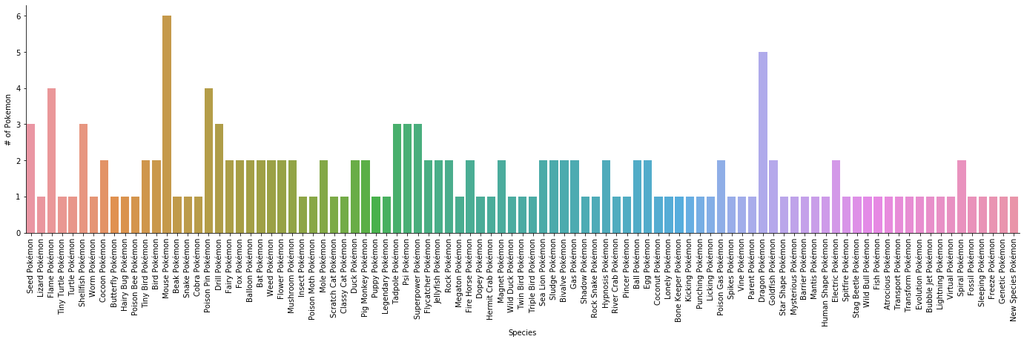

```python
import seaborn as sns
# Well almost all Pokémons are assigned to one species, thus this plot is not that interesting...
species_plot = sns.catplot(
    x='species',
    data=pokemons,
    kind='count',
    aspect=4
).set_axis_labels('Species', '# of Pokemon');
species_plot.set_xticklabels(rotation=90)
```

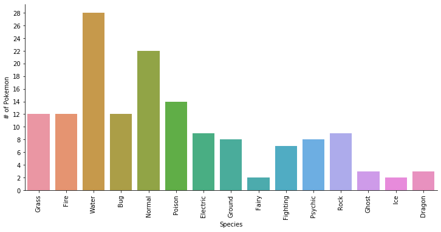

```python
pokemon_types = pokemons[['type_1']].copy()
pokemon_types = pokemon_types.rename(columns={'type_1': 'type'})
pokemon_types['type'].append(pokemons['type_2'])
# print(pokemon_types)

types_plot = sns.catplot(
    x='type',
    data=pokemon_types,
    kind='count',
    aspect=2,
).set_axis_labels('Species', '# of Pokemon');
types_plot.set_xticklabels(rotation=90)
types_plot.set(yticks=range(0,30, 2))
```

From this plot it can be seen, that the **most often** seen types are

- Water
- Normal
- Poison.

**Often** seen are

- grass
- fire
- bug

Thus a Pokémon team should be able to deal with these types. Next it would be interesting, how often these types are seen in combination.

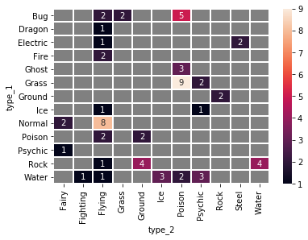

```python
pokemon_dual_types = pokemons[pokemons['type_2'] != 'None']
dual_type_plot = sns.heatmap(
    pokemon_dual_types.groupby(['type_1', 'type_2']).size().unstack(),
    linewidths=1,
    annot=True
);
dual_type_plot.set_facecolor('gray')
#dual_type_plot.set_axis_labels('Primary type', 'Secondary type')
```

So the most common combinations that one needs to be aware of are

- Grass/Poison
- Normal/Flying
- Bug/Poison
- Rock/Ground
- (Rock/Water)

Some insider knowledge: Rock/Water combinations are only seen from the Pokémons that can be caught from the fossiles and I think, one has never to fight against those vs. NPCs.

Combining the knowledge of single typed and dual typed Pokémons, it can be concluded that a team needs to deal mainly with types:

- Grass
- Normal
- Poison
- Water
- Bug

Anti-types are: It would have been cooler to get this data from the dataset. But since there are type combinations, just one of both are needed to get a higher 'against_type' value. So I looked it up from my Pokémon guide :-p.

| Type | Anti-Types |
| --- | --- |
| Grass | Fire, Ice, Poison, Flying, Psychic, Dragon |
| Normal | Rock, Ghost |
| Poison | Ground, Rock, Ghost |
| Water | Electric, Grass, Dragon |
| Bug | Fire, Ice, Flying, Ghost |

Pokémons that match this type can be filtered like this:

```python
anti_grass_pokemons = pokemons[pokemons['against_grass'] > 1] # 0 .. 2
#print(anti_grass_pokemons['german_name'].head(10))
anti_normal_pokemons = pokemons[pokemons['against_normal'] > 1]
anti_poison_pokemons = pokemons[pokemons['against_poison'] > 1]
anti_water_pokemons = pokemons[pokemons['against_water'] > 1]
anti_bug_pokemons = pokemons[pokemons['against_bug'] > 1]
```

Let's presume, I would have been able to read the above table from my dataset (I would have transformed it)

```python
types_filename = './datasets/anti_types.csv'
df_anti_types = pd.read_csv(types_filename, header=0)
df_anti_types
df_anti_types.fillna(value='None', inplace=True)
df_anti_types.head()
```

|  | grass | normal | poison | water | bug |
| --- | --- | --- | --- | --- | --- |
| 0 | fire | rock | ground | electric | fire |
| 1 | ice | ghost | rock | grass | ice |
| 2 | poison | None | ghost | dragon | flying |
| 3 | flying | None | None | None | ghost |
| 4 | psychic | None | None | None | None |

```python
df_anti_types.stack().value_counts()
```

```
None        12
ghost        3
flying       2
rock         2
dragon       2
fire         2
ice          2
poison       1
grass        1
electric     1
psychic      1
ground       1
dtype: int64
```

If summed up over the cells, we can count how often a type is present that is good against the most common types in the game. It can be seen, that a team should have a ghost, a fire, an ice, a rock, an dragon, and an flying type, since they are needed more often than the other types.

Some can be combinations as Dragon/Flying, Fire/Flying, Ice/Flying, Electric/Flying, Rock/Ground, Grass/Poison. It is also possible to combine Elements by being into one type and learning an attack of another type.

#### What are the strongest Pokémons?

```python
pokemons.sort_values('total_points', ascending=False).head(30)
```

|  | pokedex_number | german_name | is_sub_legendary | is_legendary | is_mythical | species | type_number | type_1 | type_2 | height_m | weight_kg | abilities_number | ability_1 | ability_2 | ability_hidden | total_points | hp | attack | defense | sp_attack | sp_defense | speed | catch_rate | base_experience | growth_rate | against_normal | against_fire | against_water | against_electric | … |
| --- | --- | --- | --- | --- | --- | --- | --- | --- | --- | --- | --- | --- | --- | --- | --- | --- | --- | --- | --- | --- | --- | --- | --- | --- | --- | --- | --- | --- | --- | --- |
| 188 | 150 | Mewtu | 0 | 1 | 0 | Genetic Pokémon | 1 | Psychic | None | 2 | 122 | 2 | Pressure | None | Unnerve | 680 | 106 | 110 | 90 | 154 | 90 | 130 | 3 | 306 | Slow | 1 | 1 | 1 | 1 | … |
| 191 | 151 | Mew | 0 | 0 | 1 | New Species Pokémon | 1 | Psychic | None | 0.4 | 4 | 1 | Synchronize | None | None | 600 | 100 | 100 | 100 | 100 | 100 | 100 | 45 | 270 | Medium Slow | 1 | 1 | 1 | 1 | … |
| 187 | 149 | Dragoran | 0 | 0 | 0 | Dragon Pokémon | 2 | Dragon | Flying | 2.2 | 210 | 2 | Inner Focus | None | Multiscale | 600 | 91 | 134 | 95 | 100 | 100 | 80 | 45 | 270 | Slow | 1 | 0.5 | 0.5 | 1 | … |
| 182 | 144 | Arktos | 1 | 0 | 0 | Freeze Pokémon | 2 | Ice | Flying | 1.7 | 55.4 | 2 | Pressure | None | Snow Cloak | 580 | 90 | 85 | 100 | 95 | 125 | 85 | 3 | 261 | Slow | 1 | 2 | 1 | 2 | … |
| 184 | 146 | Lavados | 1 | 0 | 0 | Flame Pokémon | 2 | Fire | Flying | 2 | 60 | 2 | Pressure | None | Flame Body | 580 | 90 | 100 | 90 | 125 | 85 | 90 | 3 | 261 | Slow | 1 | 0.5 | 2 | 2 | … |
| 183 | 145 | Zapdos | 1 | 0 | 0 | Electric Pokémon | 2 | Electric | Flying | 1.6 | 52.6 | 2 | Pressure | None | Static | 580 | 90 | 90 | 85 | 125 | 90 | 100 | 3 | 261 | Slow | 1 | 1 | 1 | 1 | … |
| 77 | 59 | Arkani | 0 | 0 | 0 | Legendary Pokémon | 1 | Fire | None | 1.9 | 155 | 3 | Intimidate | Flash Fire | Justified | 555 | 90 | 110 | 80 | 100 | 80 | 95 | 75 | 194 | Slow | 1 | 0.5 | 2 | 1 | … |
| 181 | 143 | Relaxo | 0 | 0 | 0 | Sleeping Pokémon | 1 | Normal | None | 2.1 | 460 | 3 | Immunity | Thick Fat | Gluttony | 540 | 160 | 110 | 65 | 65 | 110 | 30 | 25 | 189 | Slow | 1 | 1 | 1 | 1 | … |
| 165 | 130 | Garados | 0 | 0 | 0 | Atrocious Pokémon | 2 | Water | Flying | 6.5 | 235 | 2 | Intimidate | None | Moxie | 540 | 95 | 125 | 79 | 60 | 100 | 81 | 45 | 189 | Slow | 1 | 0.5 | 0.5 | 4 | … |
| 167 | 131 | Lapras | 0 | 0 | 0 | Transport Pokémon | 2 | Water | Ice | 2.5 | 220 | 3 | Water Absorb | Shell Armor | Hydration | 535 | 130 | 85 | 80 | 85 | 95 | 60 | 45 | 187 | Slow | 1 | 1 | 0 | 2 | … |
| 6 | 6 | Glurak | 0 | 0 | 0 | Flame Pokémon | 2 | Fire | Flying | 1.7 | 90.5 | 2 | Blaze | None | Solar Power | 534 | 78 | 84 | 78 | 109 | 85 | 100 | 45 | 240 | Medium Slow | 1 | 0.5 | 2 | 2 | … |
| 11 | 9 | Turtok | 0 | 0 | 0 | Shellfish Pokémon | 1 | Water | None | 1.6 | 85.5 | 2 | Torrent | None | Rain Dish | 530 | 79 | 83 | 100 | 85 | 105 | 78 | 45 | 239 | Medium Slow | 1 | 0.5 | 0.5 | 2 | … |
| 132 | 103 | Kokowei | 0 | 0 | 0 | Coconut Pokémon | 2 | Grass | Psychic | 2 | 120 | 2 | Chlorophyll | None | Harvest | 530 | 95 | 95 | 85 | 125 | 75 | 55 | 45 | 186 | Slow | 1 | 2 | 0.5 | 0.5 | … |
| 2 | 3 | Bisaflor | 0 | 0 | 0 | Seed Pokémon | 2 | Grass | Poison | 2 | 100 | 2 | Overgrow | None | Chlorophyll | 525 | 80 | 82 | 83 | 100 | 100 | 80 | 45 | 236 | Medium Slow | 1 | 2 | 0.5 | 0.5 | … |
| 119 | 91 | Austos | 0 | 0 | 0 | Bivalve Pokémon | 2 | Water | Ice | 1.5 | 132.5 | 3 | Shell Armor | Skill Link | Overcoat | 525 | 50 | 95 | 180 | 85 | 45 | 70 | 60 | 184 | Slow | 1 | 1 | 0.5 | 2 | … |
| 173 | 136 | Flamara | 0 | 0 | 0 | Flame Pokémon | 1 | Fire | None | 0.9 | 25 | 2 | Flash Fire | None | Guts | 525 | 65 | 130 | 60 | 95 | 110 | 65 | 45 | 184 | Medium Fast | 1 | 0 | 2 | 1 | … |
| 172 | 135 | Blitza | 0 | 0 | 0 | Lightning Pokémon | 1 | Electric | None | 0.8 | 24.5 | 2 | Volt Absorb | None | Quick Feet | 525 | 65 | 65 | 60 | 110 | 95 | 130 | 45 | 184 | Medium Fast | 1 | 1 | 1 | 0 | … |
| 171 | 134 | Aquana | 0 | 0 | 0 | Bubble Jet Pokémon | 1 | Water | None | 1 | 29 | 2 | Water Absorb | None | Hydration | 525 | 130 | 65 | 60 | 110 | 95 | 65 | 45 | 184 | Medium Fast | 1 | 0.5 | 0 | 2 | … |
| 154 | 121 | Starmie | 0 | 0 | 0 | Mysterious Pokémon | 2 | Water | Psychic | 1.1 | 80 | 3 | Illuminate | Natural Cure | Analytic | 520 | 60 | 75 | 85 | 100 | 85 | 115 | 60 | 182 | Slow | 1 | 0.5 | 0.5 | 2 | … |
| 92 | 73 | Tentoxa | 0 | 0 | 0 | Jellyfish Pokémon | 2 | Water | Poison | 1.6 | 55 | 3 | Clear Body | Liquid Ooze | Rain Dish | 515 | 80 | 70 | 65 | 80 | 120 | 100 | 60 | 180 | Slow | 1 | 0.5 | 0.5 | 2 | … |
| 179 | 142 | Aerodactyl | 0 | 0 | 0 | Fossil Pokémon | 2 | Rock | Flying | 1.8 | 59 | 3 | Rock Head | Pressure | Unnerve | 515 | 80 | 105 | 65 | 60 | 75 | 130 | 45 | 180 | Slow | 0.5 | 0.5 | 2 | 2 | … |
| 80 | 62 | Quappo | 0 | 0 | 0 | Tadpole Pokémon | 2 | Water | Fighting | 1.3 | 54 | 3 | Water Absorb | Damp | Swift Swim | 510 | 90 | 95 | 95 | 70 | 90 | 70 | 45 | 230 | Medium Slow | 1 | 0.5 | 0 | 2 | … |
| 50 | 38 | Vulnona | 0 | 0 | 0 | Fox Pokémon | 1 | Fire | None | 1.1 | 19.9 | 2 | Flash Fire | None | Drought | 505 | 73 | 76 | 75 | 81 | 100 | 100 | 75 | 177 | Medium Fast | 1 | 0 | 2 | 1 | … |
| 45 | 34 | Nidoking | 0 | 0 | 0 | Drill Pokémon | 2 | Poison | Ground | 1.4 | 62 | 3 | Poison Point | Rivalry | Sheer Force | 505 | 81 | 102 | 77 | 85 | 75 | 85 | 45 | 227 | Medium Slow | 1 | 1 | 2 | 0 | … |
| 42 | 31 | Nidoqueen | 0 | 0 | 0 | Drill Pokémon | 2 | Poison | Ground | 1.3 | 60 | 3 | Poison Point | Rivalry | Sheer Force | 505 | 90 | 92 | 87 | 75 | 85 | 76 | 45 | 227 | Medium Slow | 1 | 1 | 2 | 0 | … |
| 87 | 68 | Machomei | 0 | 0 | 0 | Superpower Pokémon | 1 | Fighting | None | 1.6 | 130 | 3 | Guts | No Guard | Steadfast | 505 | 90 | 130 | 80 | 65 | 85 | 55 | 45 | 227 | Medium Slow | 1 | 1 | 1 | 1 | … |
| 161 | 127 | Pinsir | 0 | 0 | 0 | Stag Beetle Pokémon | 1 | Bug | None | 1.5 | 55 | 3 | Hyper Cutter | Mold Breaker | Moxie | 500 | 65 | 125 | 100 | 55 | 70 | 85 | 45 | 175 | Slow | 1 | 2 | 1 | 1 | … |
| 83 | 65 | Simsala | 0 | 0 | 0 | Psi Pokémon | 1 | Psychic | None | 1.5 | 48 | 3 | Synchronize | Inner Focus | Magic Guard | 500 | 55 | 50 | 45 | 135 | 95 | 120 | 50 | 225 | Medium Slow | 1 | 1 | 1 | 1 | … |
| 101 | 78 | Gallopa | 0 | 0 | 0 | Fire Horse Pokémon | 1 | Fire | None | 1.7 | 95 | 3 | Run Away | Flash Fire | Flame Body | 500 | 65 | 100 | 70 | 80 | 80 | 105 | 60 | 175 | Medium Fast | 1 | 0.5 | 2 | 1 | … |
| 116 | 89 | Sleimok | 0 | 0 | 0 | Sludge Pokémon | 1 | Poison | None | 1.2 | 30 | 3 | Stench | Sticky Hold | Poison Touch | 500 | 105 | 105 | 75 | 65 | 100 | 50 | 75 | 175 | Medium Fast | 1 | 1 | 1 | 1 | … |

Example team: Dragoran, some ghost, Kokowei, Aerodactyl, Nidoking, Lapras, Arkani